# v0.4.2 paper-figure candidates, v2 (Science Advances)

Made 2026-11-26 15:52 PST by `workflow/08_figures/model_figures.py paper` (branch paper/model-figures, 7aea31dd). Candidates for the PI to choose from; nothing is in paper_sciadv/figures/. Files (vector PDF with rasterised colour fields and events, and PNG 300 dpi): `/wd1/mdenolle_data/tomo_v1/models/figures_v0.4.2/paper_candidates_v2`. Previews below are 150 dpi; click a preview for the PDF. Width 17.8 cm (two columns); heights at or under 20 cm.

**Model**: v0.4.2 only (latest). **Colour** (palette sheet: palette_sheet.html): Vp, Vs batlow reversed (slow warm, fast cool); Vp/Vs roma reversed centred on 1.75 (high warm); differences vik reversed centred on 0 (slow warm). **Style**: sans-serif (Nimbus Sans = Helvetica metrics, as the GMT figures of v4_figures.py) 5-7 pt, frame 0.5 pt, panel letters 8 pt bold; shaded relief as the base map.

**Model, mask and inputs**

**Model** `/wd1/mdenolle_data/tomo_v1/models/cascadia_obs_tomo/v0.4.2.nc` · cascadia_obs_tomo.v0.4.2 · data revision r0.4.2 · sha256 `45880409101f5d94`  
cascadia_obs_tomo v0.4.2: v0.4.1 (re-timed picks, D-B081 floor in the inversion) with the self-paired catalog differential times of the mendocino_gorda_c, blanco and washington tiles removed (8 events paired with themselves, read by tomoDD as absolute times of 0 s) and those tiles re-inverted with the patched tomoDD-SE (stable sph2car/car2sph near the tile centre axis), D-B099; product as D-B076: medium (rock / water / air at the D-B068 merged surface), D-B073 shallow-crust node rule, Vp_tomography / Vs_tomography = the inversion values

**Grid** 118 latitudes 38.9–50.6°N (0.1°) × 94 longitudes -131.75–-120.125° (0.125°) × 21 depths (km below sea level, uneven): -3, -1, 1, 3, 5, 7, 9, 12, 15, 18, 21, 25, 29, 34, 40, 47, 55, 65, 80, 100, 125. Node spacing about 11 km N–S and 9–10 km E–W.

**Shown cells** (mask `either`): rock nodes only (`medium = 0`; nothing above the seafloor or ground) that are **checkerboard-resolved** (`resolution_p/s > 0`, D-B018: local correlation ≥ 0.7 and amplitude ≥ 0.5, finest of 40/60/100 km cells) **or well sampled** (`DWS ≥ 100`); P for Vp and dVp, S for Vs and dVs, both for Vp/Vs; and data-derived (`tile_weight > 0`; for Vs also `vs_reverted = 0` and not a D-B073 shallow-crust node). **Which rule passes**: cells inside the black outline are checkerboard-resolved; the rest pass on DWS only. The checkerboard-resolved set is small (table) and empty at 21, 25 and 34–60 km, so those depths are DWS-only. Between nodes: multilinear interpolation over shown nodes only, drawn only where the nearest node is shown (no value is made from a masked node).

**Overlays**: catalogue `/wd1/mdenolle_data/catalog_v6/v6.0/cascadia_catalog_v6.0.csv`, tiers ABC (139,247 of 172,342 events), maps: events between the mid-depths to the neighbouring nodes; sections: within ±10 km. Stations: ver5 table (`in_ver5`, ▲ land, ▼ ocean bottom). Coast: GMT high resolution. Plate boundaries and trench: PB2002 (Bird 2003). Slab2 top: `/home/mdenolle/cascadia_obs_ensemble/data/slab2/cas_slab2_dep.xyz`. Topography/bathymetry: GMT earth_relief 01m. Missing inputs:

- none

**Node counts per depth** (rock nodes, checkerboard-resolved, DWS ≥ 100, shown)**

| depth_km | rock | checker_P | checker_S | DWS_P>=100 | DWS_S>=100 | shown_Vp | shown_Vs | shown_VpVs |
| --- | --- | --- | --- | --- | --- | --- | --- | --- |
| -3.0 | 1 | 0 | 0 | 0 | 0 | 0 | 0 | 0 |
| -1.0 | 1777 | 0 | 0 | 4 | 0 | 4 | 0 | 0 |
| 1.0 | 5060 | 20 | 0 | 88 | 10 | 88 | 10 | 10 |
| 3.0 | 8586 | 38 | 0 | 119 | 13 | 119 | 13 | 13 |
| 5.0 | 11092 | 51 | 0 | 169 | 23 | 154 | 23 | 23 |
| 7.0 | 11092 | 52 | 1 | 241 | 33 | 192 | 34 | 33 |
| 9.0 | 11092 | 21 | 0 | 408 | 64 | 303 | 57 | 57 |
| 12.0 | 11092 | 4 | 1 | 637 | 119 | 485 | 91 | 86 |
| 15.0 | 11092 | 256 | 188 | 780 | 191 | 794 | 290 | 282 |
| 18.0 | 11092 | 313 | 110 | 793 | 218 | 812 | 277 | 266 |
| 21.0 | 11092 | 0 | 0 | 746 | 158 | 619 | 125 | 125 |
| 25.0 | 11092 | 0 | 0 | 672 | 132 | 571 | 110 | 110 |
| 29.0 | 11092 | 133 | 20 | 471 | 109 | 450 | 114 | 114 |
| 34.0 | 11092 | 0 | 0 | 260 | 14 | 204 | 13 | 13 |
| 40.0 | 11092 | 0 | 0 | 48 | 0 | 39 | 0 | 0 |
| 47.0 | 11092 | 0 | 0 | 10 | 0 | 10 | 0 | 0 |
| 55.0 | 11092 | 0 | 0 | 7 | 0 | 7 | 0 | 0 |

## Fig. M1: model overview, Vp, Vs and Vp/Vs at 9, 18 and 29 km (3 × 3)

figM1_overview.pdf · figM1_overview.png (17.8 × 19.9 cm)

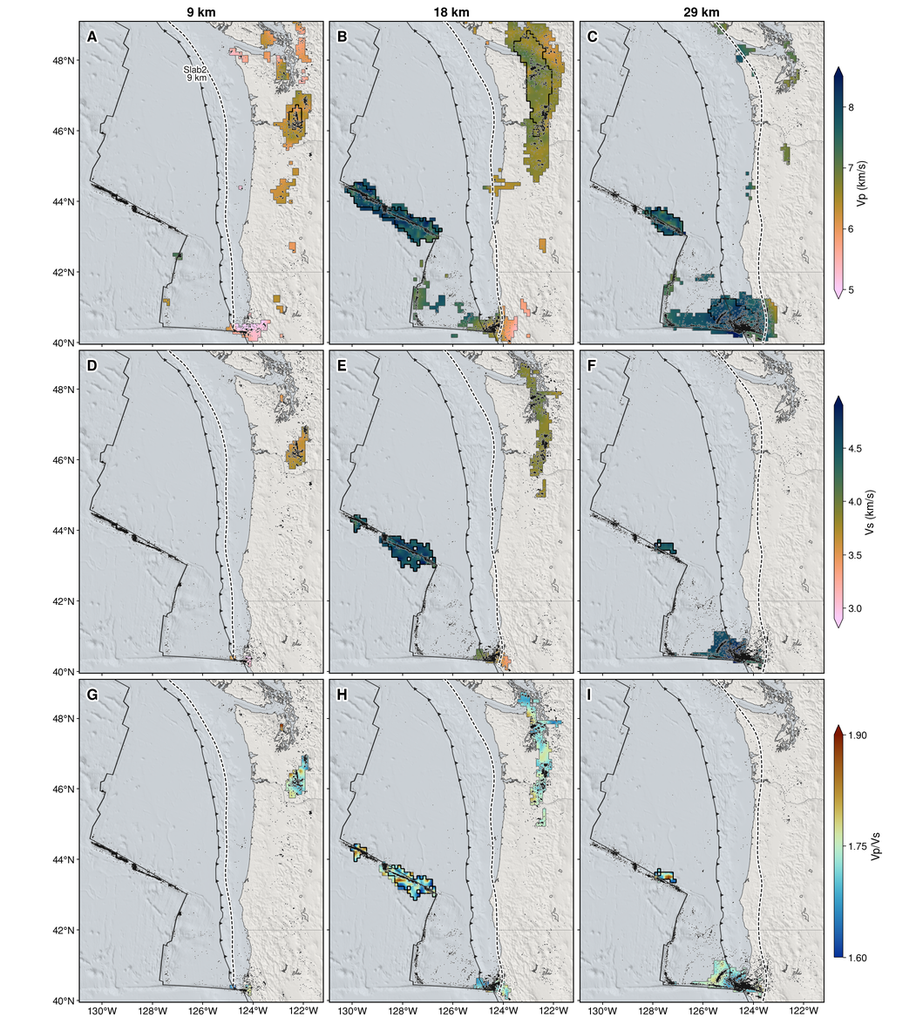

## Fig. M1, alternative: two depths (18 and 29 km, 2 × 3)

figM1b_two_depths.pdf · figM1b_two_depths.png (17.8 × 16.6 cm)

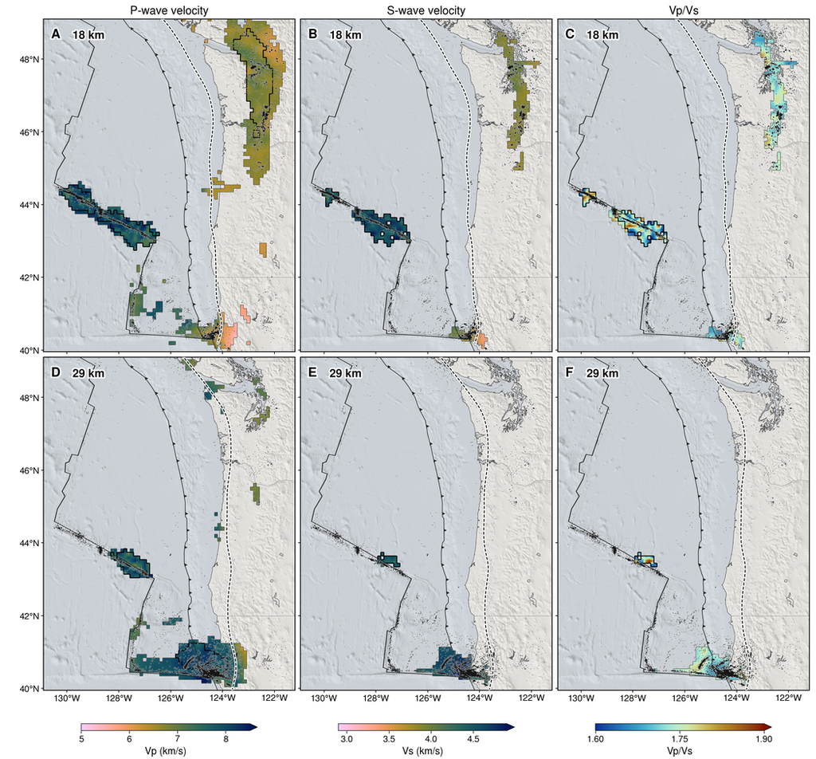

## Fig. M2: margin-normal Vp/Vs sections

**Caption draft (facts only):** Vp/Vs of model v0.4.2 along four margin-normal profiles (B-E), located in A (purple: Vp/Vs shown at one depth or more; lines with teeth: subduction front). Profiles: B Mendocino 40.4°N (126.4°W to 122.4°W); C Gorda 40.9°N (126.4°W to 122.4°W); D Blanco 43.5°N (129.4°W to 125.4°W); E S. Washington 46.4°N (125°W to 121°W); 4° of longitude each, vertical exaggeration about 1.6. Colour only where Vp and Vs are both shown (same rule as Fig. M1); black outline: checkerboard-resolved; light grey: below the seafloor or ground, not shown; pale blue: water; colour bar and symbol legend under A. Contours: Vp 6.0 to 8.0 km/s every 0.5 km/s, drawn only through cells where Vp is shown (pieces shorter than 10 km omitted). Dots: catalogue cascadia_catalog_v6.0.csv tiers ABC events within ±10 km of the profile. Dashed: Slab2 top (Hayes et al. 2018). Black line: seafloor or ground (GMT earth_relief 01m). Colour map: roma reversed (Crameri 2018), centred on 1.75.

figM2_sections.pdf · figM2_sections.png (17.8 × 13.1 cm)

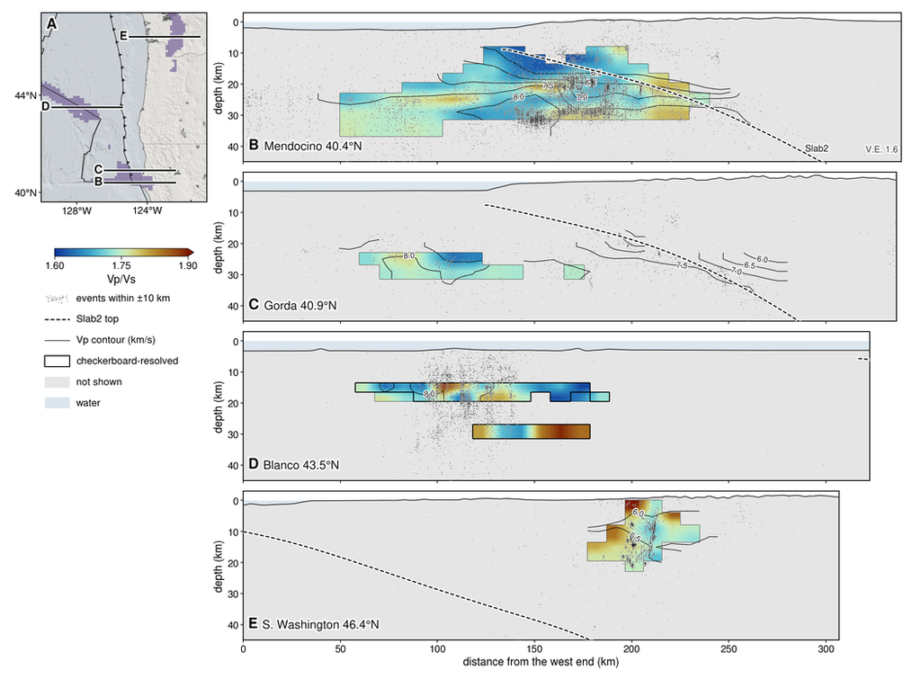

## Fig. M3 (slot): ensemble uncertainty of v0.4.2

Reserved for the node uncertainty of v0.4.2 from the 100-member randomize-then-optimize ensemble (D-B030, D-B032), registered tonight; not made here. Planned layout as Fig. M1 (rows Vp, Vs, Vp/Vs; columns 9, 18, 29 km; calibrated standard deviation, one colour bar per variable, same mask), with a sequential map distinct from batlow reversed.

## Fig. S-M3: resolution (checkerboard, DWS)

**Caption draft (facts only):** Resolution of model v0.4.2 at 9, 18, 29 km below sea level. A-B, E-F, I-J: finest checkerboard cell (40, 60 or 100 km; ±8 % patterns in the depth bands -10, 12, 25, 40 and 65 km) recovered with local correlation ≥ 0.7 and amplitude ≥ 0.5 (D-B018), finest over the covering tiles, P and S (dark: 40 km, light: 100 km). C-D, G-H, K-L: merge-weighted derivative weight sum (DWS), P and S; black contour: DWS = 100. Node counts in the upper left. Uncoloured: shaded relief. Colour maps: bamako (3 classes) and devon reversed (Crameri 2018).

figSM3_resolution.pdf · figSM3_resolution.png (17.8 × 18.4 cm)

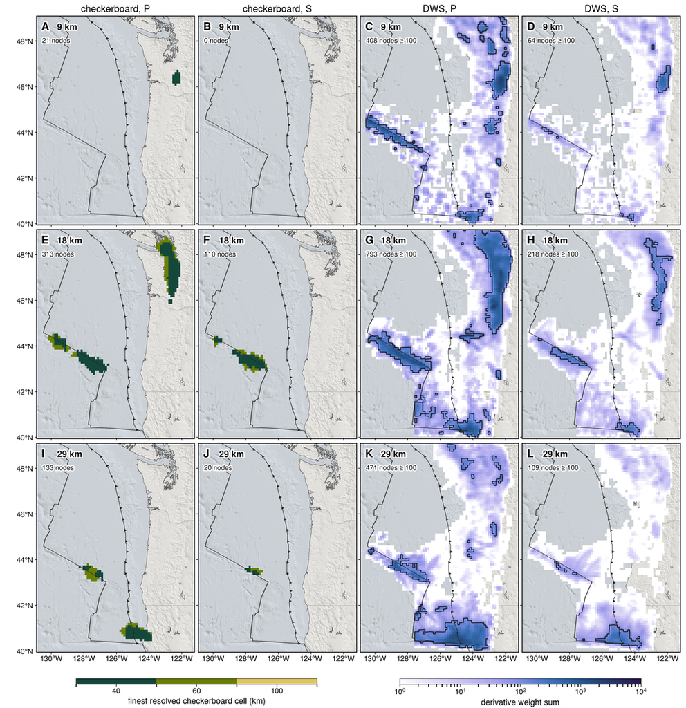

## Fig. S-M4: comparison with published Vs models

**Caption draft (facts only):** S-wave velocity of model v0.4.2 (first column; shown cells as in Fig. M1) and of Delph et al. (2018) and CRESCENT CVM Gen0 (Delph, Levander & Niu 2018, Geophys. Res. Lett. 45(20), doi:10.1029/2018GL079518; CRESCENT Gen0 Community Velocity Model, He 2026, doi:10.6084/m9.figshare.31902061) at 9, 18, 29 km below sea level, and the difference 100 (Vs / Vs_prior − 1) at the shown nodes of this study (last two columns). Prior models are sampled at the same depth (linear in depth) on their own grids and drawn over rock only. One Vs scale (2.9-4.9 km/s, as Fig. M1) for all panels; number of compared nodes and median difference in the lower left of each difference panel. Colour maps: batlow reversed and vik reversed (Crameri 2018).

figSM4_prior_models.pdf · figSM4_prior_models.png (17.8 × 15.2 cm)

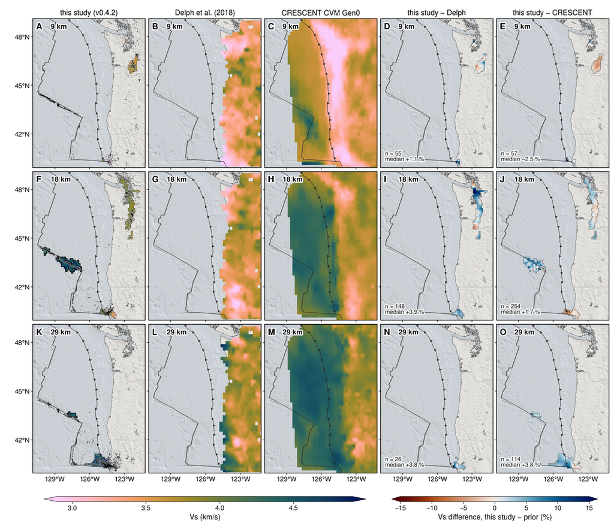

**Differences per depth (this study − prior, % of prior)**

| depth_km | prior | n_nodes | median_pct | mad_pct | rms_pct |
| --- | --- | --- | --- | --- | --- |
| 9.0 | Delph et al. (2018) | 55 | 1.09 | 2.02 | 4.34 |
| 9.0 | CRESCENT CVM Gen0 | 57 | -2.47 | 1.78 | 4.29 |
| 18.0 | Delph et al. (2018) | 148 | 3.92 | 2.52 | 6.15 |
| 18.0 | CRESCENT CVM Gen0 | 254 | 1.74 | 2.06 | 3.92 |
| 29.0 | Delph et al. (2018) | 26 | 3.79 | 0.98 | 5.36 |
| 29.0 | CRESCENT CVM Gen0 | 114 | 3.77 | 1.59 | 4.51 |

Citation: the Delph model is Delph, Levander & Niu (2018), GRL 45(20), doi:10.1029/2018GL079518. The EMC netCDF's attribute naming Ward & Lin is wrong and is not used.